# Master Thesis 5.0

Marijan Rancic

10/10/2020

## Set working directory

This Chunk is optional and prior run it, please make sure you have your project working directory set.

## Problem description

This is one of the final versions of the file. Working versions in which, some models were discussed and/or optmized will be delivered under working files directory.

Dependent variables: - HU - HU-RS

Predictors: - WGenRO - GenHU - FLoadHU - TempHU

as well as lagged values of these predictors and the dependent variables are also allowed.

## Load libraries

```r
library(readxl)
library(lubridate)
library(fastDummies)
library(tidyverse)
library(prophet)
library(randomForest)
library(gbm)
```

## Import data

```r
prices<-read_excel("Data/MainDB.xlsx") #This is under MR working directory structure. Make sure you have the same structure or full link to the files.
holidays<-read_excel("Data/HollidayHU.xlsx")

prices<-prices%>%
  left_join(holidays,by=c("datum"="Date"))%>%
  rename("Holiday"="Flag")%>%
  replace_na(list(Holiday=0))

prices$DHour<-factor(prices$DHour)
prices$hour_num<-hour(dmy_hm(prices$date.time))
prices$weekday<-factor(weekdays(prices$datum))
prices$month<-factor(months(prices$datum))
prices$HU_RS=prices$HU-prices$RS
```

## Generate dummy variables for weekday, month and hour

```r
prices <- dummy_cols(prices,
                     select_columns = c('weekday', 'month','DHour'),
                     remove_selected_columns = TRUE)
```

## Inspect autocorrelation patterns

Lag 1 cannot be accounted for, but may represent some trend. Lag 24 can be accounted for.

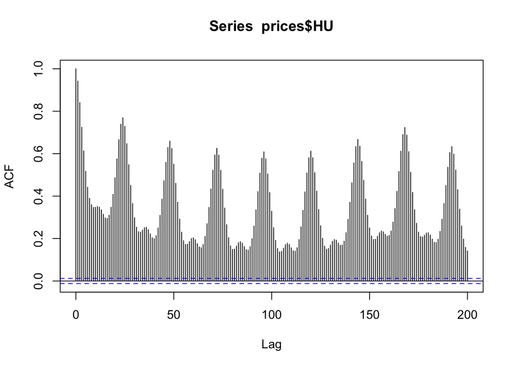

```r
acf(prices$HU, lag.max=200, plot=TRUE)
```

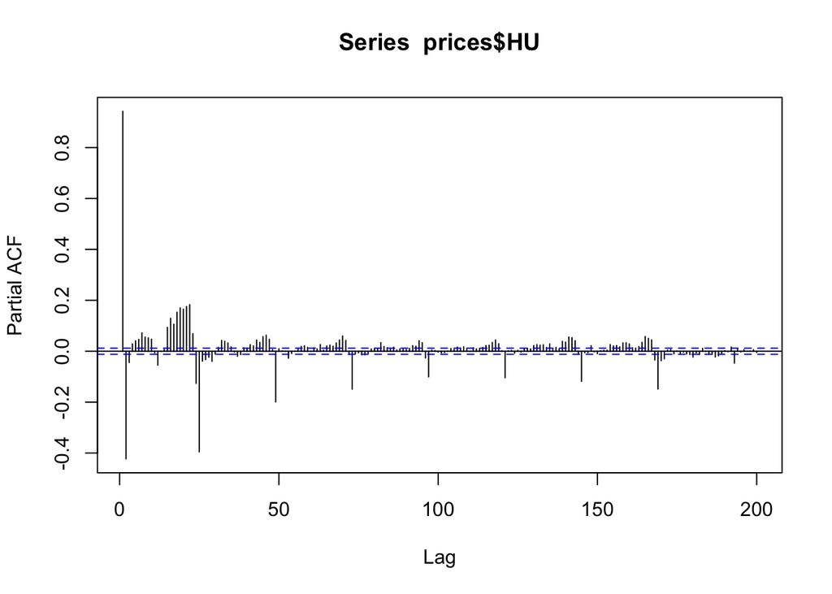

```r
pacf(prices$HU, lag.max=200, plot=TRUE)
```

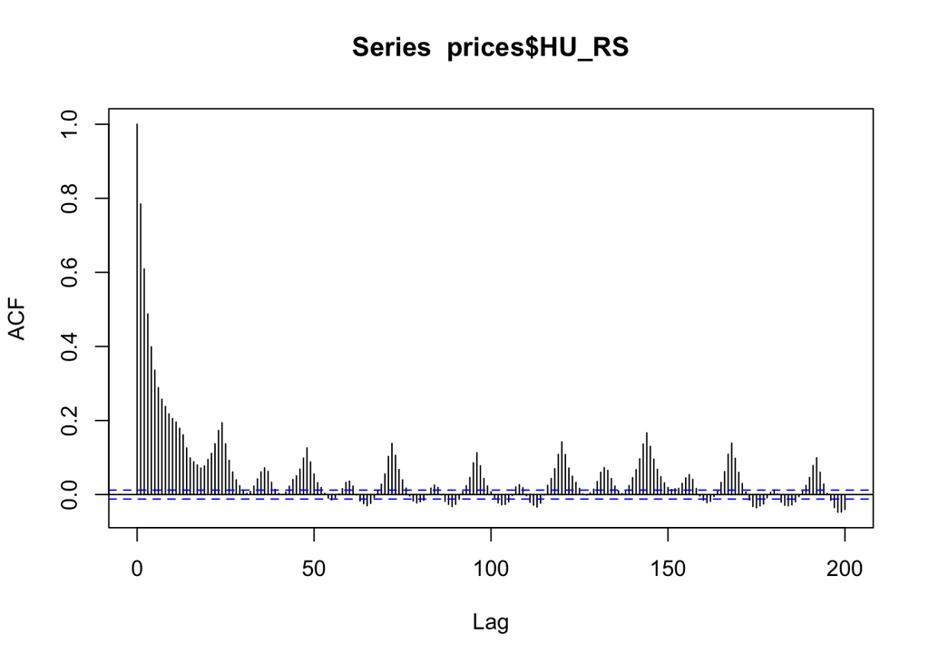

```r
acf(prices$HU_RS, lag.max=200, plot=TRUE)
```

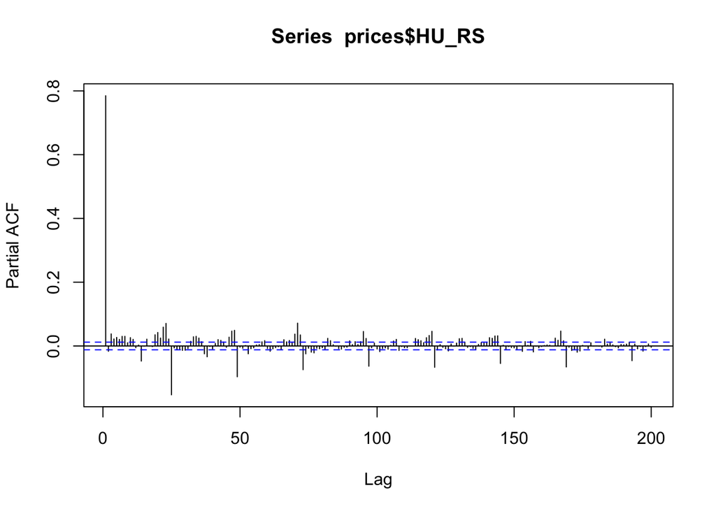

```r
pacf(prices$HU_RS, lag.max=200, plot=TRUE)
```

## Stationarity test

Both series of interest are stationary

```r
library(tseries)
adf.test(prices$HU)
```

```
##
##  Augmented Dickey-Fuller Test
##
## data:  prices$HU
## Dickey-Fuller = -13.939, Lag order = 29, p-value = 0.01
## alternative hypothesis: stationary
```

```r
adf.test(prices$HU_RS)
```

```
##
##  Augmented Dickey-Fuller Test
##
## data:  prices$HU_RS
## Dickey-Fuller = -24.327, Lag order = 29, p-value = 0.01
## alternative hypothesis: stationary
```

## Plots of relationships

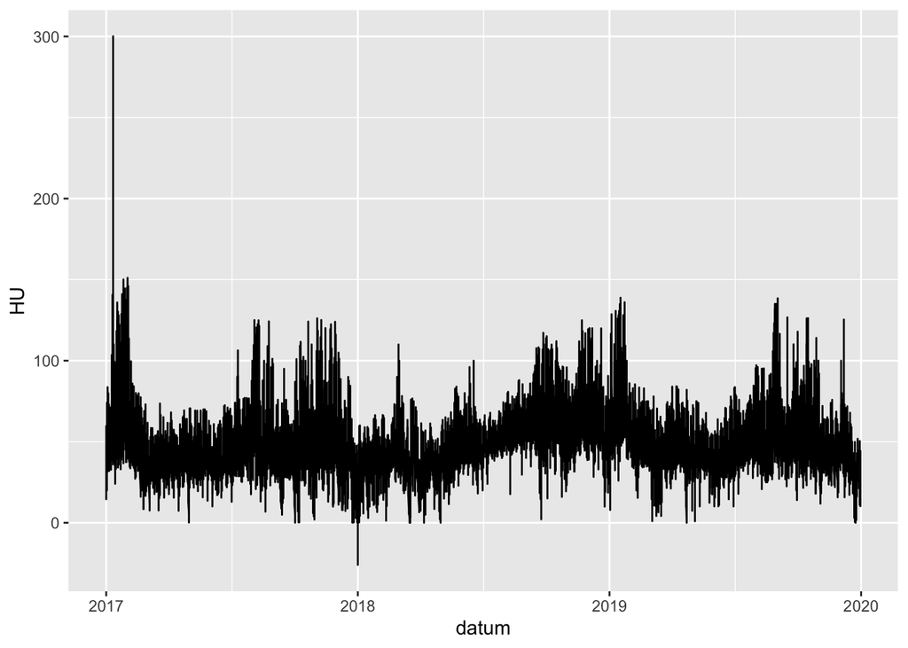

```r
library(ggplot2)
ggplot(data=prices, aes(x=datum,y=HU))+geom_line()
```

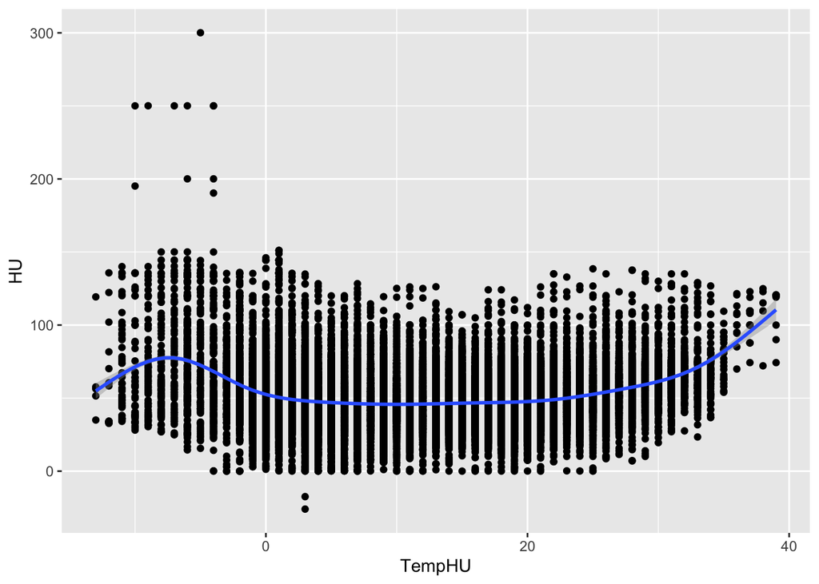

```r
ggplot(data=prices,aes(x=TempHU,y=HU))+
  geom_point()+
  geom_smooth()
```

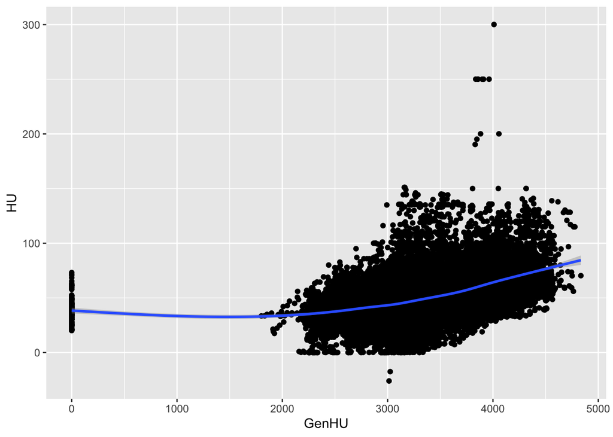

```r
ggplot(data=prices,aes(x=GenHU,y=HU))+
  geom_point()+
  geom_smooth()
```

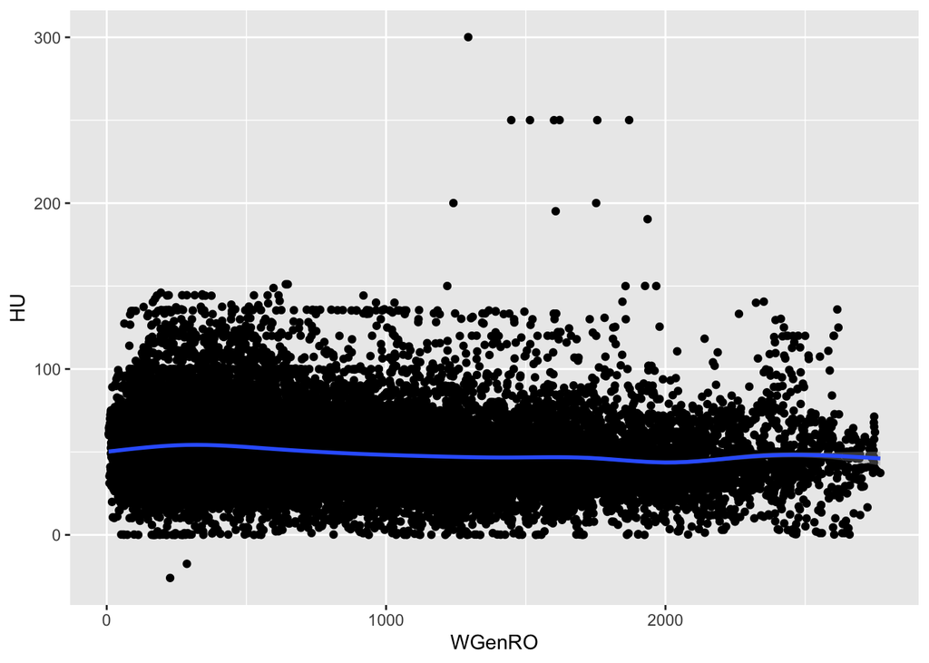

```r
ggplot(data=prices,aes(x=WGenRO,y=HU))+
  geom_point()+
  geom_smooth()
```

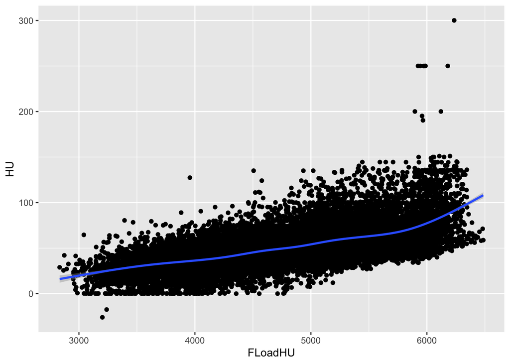

```r
ggplot(data=prices,aes(x=FLoadHU,y=HU))+
  geom_point()+
  geom_smooth()
```

## Generate lagged values

We allow our models to include lagged values of the dependent variable (24 hours ago), as well as lagged values of predictors (24 hours ago and 1 hour ago) in addition to variables reflecting weekday, month, hour and the values of predictors in the hour for which the prediction is made.

```r
library("Hmisc")
# generate all sensible lags to be used as predictors
prices$HU_lag24=Lag(prices$HU,24)
prices$RS_lag24=Lag(prices$RS,24)

prices$WGenRO_lag24=Lag(prices$WGenRO,24)
prices$GenHU_lag24=Lag(prices$GenHU,24)
prices$FLoadHU_lag24=Lag(prices$FLoadHU,24)
prices$TempHU_lag24=Lag(prices$TempHU,24)

prices$WGenRO_lag1=Lag(prices$WGenRO,1)
prices$GenHU_lag1=Lag(prices$GenHU,1)
prices$FLoadHU_lag1=Lag(prices$FLoadHU,1)
prices$TempHU_lag1=Lag(prices$TempHU,1)

prices$WGenRO_lag2=Lag(prices$WGenRO,2)
prices$GenHU_lag2=Lag(prices$GenHU,2)
prices$FLoadHU_lag2=Lag(prices$FLoadHU,2)
prices$TempHU_lag2=Lag(prices$TempHU,2)
```

## Baseline regression models to see which ones make sense.

```r
reg_HU=lm(HU~.-RS-HU_RS-`FlowHU-RS`-`FlowHU-RO`-hour_num,data=select_if(prices,is.numeric))
summary(reg_HU)
```

```
##
## Call:
## lm(formula = HU ~ . - RS - HU_RS - `FlowHU-RS` - `FlowHU-RO` -
##     hour_num, data = select_if(prices, is.numeric))
##
## Residuals:
##     Min      1Q  Median      3Q     Max
## -98.510  -5.125  -0.213   4.597 170.253
##
## Coefficients: (3 not defined because of singularities)
##                     Estimate Std. Error t value Pr(>|t|)
## (Intercept)       -1.101e+01  1.295e+00  -8.505  < 2e-16 ***
## WGenRO            -2.426e-03  1.051e-03  -2.308 0.020994 *
## GenHU              2.059e-03  6.415e-04   3.210 0.001330 **
## FLoadHU            1.885e-02  6.084e-04  30.987  < 2e-16 ***
## TempHU            -1.579e-01  7.458e-02  -2.117 0.034298 *
## Holiday            2.783e-01  2.722e-01   1.022 0.306601
## weekday_Friday    -1.123e+00  2.245e-01  -5.001 5.73e-07 ***
## weekday_Monday     3.700e+00  2.621e-01  14.118  < 2e-16 ***
## weekday_Saturday  -5.950e-01  2.529e-01  -2.353 0.018642 *
## weekday_Sunday    -3.668e+00  2.649e-01 -13.844  < 2e-16 ***
## weekday_Thursday  -8.862e-01  2.239e-01  -3.958 7.56e-05 ***
## weekday_Tuesday    6.872e-01  2.253e-01   3.050 0.002287 **
## weekday_Wednesday         NA         NA      NA       NA
## month_April       -3.761e+00  3.185e-01 -11.806  < 2e-16 ***
## month_August       2.338e+00  3.146e-01   7.433 1.09e-13 ***
## month_December    -7.046e+00  4.219e-01 -16.701  < 2e-16 ***
## month_February    -8.003e+00  4.351e-01 -18.395  < 2e-16 ***
## month_January     -4.189e+00  4.529e-01  -9.250  < 2e-16 ***
## month_July         6.146e-01  3.057e-01   2.011 0.044378 *
## month_June        -2.025e+00  3.130e-01  -6.470 9.96e-11 ***
## month_March       -6.374e+00  3.802e-01 -16.763  < 2e-16 ***
## month_May         -2.074e+00  3.110e-01  -6.670 2.61e-11 ***
## month_November    -2.897e+00  3.496e-01  -8.286  < 2e-16 ***
## month_October     -5.806e-01  3.049e-01  -1.904 0.056892 .
## month_September           NA         NA      NA       NA
## DHour_H01          7.208e-01  4.174e-01   1.727 0.084192 .
## DHour_H02          1.003e+00  4.281e-01   2.342 0.019185 *
## DHour_H03          1.460e+00  4.443e-01   3.285 0.001021 **
## DHour_H04          2.102e+00  4.617e-01   4.552 5.33e-06 ***
```

[output cut: 26 more lines]

```
## WGenRO_lag1       -5.460e-03  1.944e-03  -2.809 0.004973 **
## GenHU_lag1        -1.102e-03  9.453e-04  -1.166 0.243635
## FLoadHU_lag1      -3.487e-03  9.486e-04  -3.676 0.000238 ***
## TempHU_lag1        3.488e-02  1.001e-01   0.348 0.727536
## WGenRO_lag2        2.188e-03  1.057e-03   2.069 0.038541 *
## GenHU_lag2        -7.313e-05  6.466e-04  -0.113 0.909954
## FLoadHU_lag2       5.792e-04  5.821e-04   0.995 0.319789
## TempHU_lag2        7.700e-02  7.467e-02   1.031 0.302435
## ---
## Signif. codes:  0 '***' 0.001 '**' 0.01 '*' 0.05 '.' 0.1 ' ' 1
##
## Residual standard error: 9.657 on 26144 degrees of freedom
##   (76 observations deleted due to missingness)
## Multiple R-squared:  0.7849, Adjusted R-squared:  0.7844
## F-statistic:  1617 on 59 and 26144 DF,  p-value: < 2.2e-16
```

```r
reg_HU_RS=lm(HU_RS~.-RS-HU-`FlowHU-RS`-`FlowHU-RO`-hour_num,data=select_if(prices,is.numeric))
summary(reg_HU_RS)
```

```
##
## Call:
## lm(formula = HU_RS ~ . - RS - HU - `FlowHU-RS` - `FlowHU-RO` -
##     hour_num, data = select_if(prices, is.numeric))
##
## Residuals:
##     Min      1Q  Median      3Q     Max
## -82.218  -3.358  -0.171   3.099 125.190
##
## Coefficients: (3 not defined because of singularities)
##                     Estimate Std. Error t value Pr(>|t|)
## (Intercept)       -1.727e+01  1.047e+00 -16.497  < 2e-16 ***
## WGenRO            -2.934e-04  8.501e-04  -0.345 0.729991
## GenHU              3.663e-05  5.188e-04   0.071 0.943721
## FLoadHU            9.449e-03  4.920e-04  19.205  < 2e-16 ***
## TempHU            -1.398e-01  6.032e-02  -2.317 0.020496 *
## Holiday            8.017e-01  2.201e-01   3.642 0.000271 ***
## weekday_Friday     1.584e-01  1.816e-01   0.873 0.382918
## weekday_Monday     3.695e-01  2.120e-01   1.743 0.081286 .
## weekday_Saturday   1.604e+00  2.045e-01   7.841 4.63e-15 ***
## weekday_Sunday     1.046e+00  2.143e-01   4.883 1.05e-06 ***
## weekday_Thursday  -3.356e-01  1.811e-01  -1.854 0.063821 .
## weekday_Tuesday   -6.744e-01  1.822e-01  -3.702 0.000215 ***
## weekday_Wednesday         NA         NA      NA       NA
## month_April       -1.213e-01  2.576e-01  -0.471 0.637769
## month_August       2.641e-01  2.544e-01   1.038 0.299197
## month_December    -2.775e+00  3.412e-01  -8.132 4.39e-16 ***
## month_February    -2.686e+00  3.519e-01  -7.632 2.38e-14 ***
## month_January     -2.200e+00  3.663e-01  -6.005 1.93e-09 ***
## month_July         4.276e-01  2.472e-01   1.730 0.083707 .
## month_June        -5.925e-01  2.531e-01  -2.340 0.019268 *
## month_March        4.235e-01  3.075e-01   1.377 0.168489
## month_May          8.623e-01  2.515e-01   3.429 0.000607 ***
## month_November    -1.060e+00  2.828e-01  -3.747 0.000179 ***
## month_October     -3.565e-01  2.466e-01  -1.446 0.148312
## month_September           NA         NA      NA       NA
## DHour_H01          9.183e-01  3.375e-01   2.720 0.006525 **
## DHour_H02          1.972e+00  3.462e-01   5.696 1.24e-08 ***
## DHour_H03          3.056e+00  3.593e-01   8.506  < 2e-16 ***
## DHour_H04          3.999e+00  3.734e-01  10.708  < 2e-16 ***
```

[output cut: 26 more lines]

```
## WGenRO_lag1       -5.791e-03  1.572e-03  -3.684 0.000230 ***
## GenHU_lag1        -1.006e-03  7.645e-04  -1.316 0.188104
## FLoadHU_lag1      -5.518e-03  7.671e-04  -7.193 6.51e-13 ***
## TempHU_lag1        7.659e-02  8.096e-02   0.946 0.344161
## WGenRO_lag2        4.241e-03  8.552e-04   4.959 7.12e-07 ***
## GenHU_lag2         6.774e-04  5.229e-04   1.295 0.195206
## FLoadHU_lag2       1.614e-03  4.708e-04   3.428 0.000610 ***
## TempHU_lag2        7.226e-02  6.039e-02   1.197 0.231466
## ---
## Signif. codes:  0 '***' 0.001 '**' 0.01 '*' 0.05 '.' 0.1 ' ' 1
##
## Residual standard error: 7.81 on 26144 degrees of freedom
##   (76 observations deleted due to missingness)
## Multiple R-squared:  0.1392, Adjusted R-squared:  0.1373
## F-statistic: 71.68 on 59 and 26144 DF,  p-value: < 2.2e-16
```

## Time series cross-validation

Create a vector of 30 random test dates (parameter size=30) from 2019 data (a potential pool of 365 days). If you want to apply each model to a single date, just specify only this date as both start and end date and size=1 it will choose only from 1 date. In this example, the forecast will be for May 25 2019 only.

```r
library(lubridate)
set.seed(100)
test_dates<-sample(seq.Date(ymd("2019-05-25"),ymd("2019-05-25"),by=1),size=1) #amend size to desired pool
```

```r
# set counter to 0 (will change in a loop)
k=0

# create empty vectors for MAE, MAPE and RMSE
arima_mae_HU=numeric()
arima_mape_HU=numeric()
arima_rmse_HU=numeric()

# loop
for (i in seq_along(test_dates)){
date=test_dates[i]


# split sample
training<-subset(prices, ymd(datum)<date)
testing<-subset(prices, ymd(datum)==date)

# rename variables so that they correspond to input expected by the prophet algorithm.
#arima <- step(lm(HU~.-RS-HU_RS-`FlowHU-RS`-`FlowHU-RO`,data=select_if(na.omit(training),is.numeric)))
arima <- lm(HU~.-RS-HU_RS-`FlowHU-RS`-`FlowHU-RO`-hour_num,data=select_if(na.omit(training),is.numeric))
forecast_arima_HU <- predict(arima, na.omit(testing))
k=k+1
arima_mae_HU[k]=mean(abs(forecast_arima_HU -testing$HU))
arima_mape_HU[k]=mean(abs((forecast_arima_HU -testing$HU)/(testing$HU)*100))
arima_rmse_HU[k]=sqrt(mean(abs(forecast_arima_HU-testing$HU)^2))
}

## Print mean error measures based on all dates included in testing
mean(arima_mae_HU)
```

```
## [1] 2.123333
```

```r
mean(arima_mape_HU)
```

```
## [1] 5.740275
```

```r
mean(arima_rmse_HU)
```

```
## [1] 2.809378
```

```r
# set counter to 0 (will change in a loop)
k=0

# create empty vectors for MAE, MAPE and RMSE
arima_mae_HU_RS=numeric()
arima_mape_HU_RS=numeric()
arima_rmse_HU_RS=numeric()
arima_mde_HU_RS=numeric()
# loop
for (i in seq_along(test_dates)){
date=test_dates[i]


# split sample
training<-subset(prices, ymd(datum)<date)
testing<-subset(prices, ymd(datum)==date)

# rename variables so that they correspond to input expected by the prophet algorithm.
arima <- lm(HU_RS~.-RS-HU-`FlowHU-RS`-`FlowHU-RO`-hour_num,data=select_if(na.omit(training),is.numeric))
forecast_arima_HU_RS <- predict(arima, na.omit(testing))
k=k+1
arima_mae_HU_RS[k]=mean(abs(forecast_arima_HU_RS-testing$HU_RS))
arima_mape_HU_RS[k]=mean(abs((forecast_arima_HU_RS-testing$HU_RS)/(testing$HU_RS)*100))
arima_mde_temp = mean(testing$HU_RS)
arima_mde_HU_RS[k]=mean(abs((forecast_arima_HU_RS-testing$HU_RS)/(arima_mde_temp)*100))
arima_rmse_HU_RS[k]=sqrt(mean(abs(forecast_arima_HU_RS-testing$HU_RS)^2))
}

## Print mean error measures based on all dates included in testing
mean(arima_mae_HU_RS)
```

```
## [1] 1.924931
```

```r
mean(arima_mape_HU_RS)
```

```
## [1] 323.9702
```

```r
mean(arima_rmse_HU_RS)
```

```
## [1] 2.239207
```

```r
mean(arima_mde_HU_RS)
```

```
## [1] 169.7844
```

## Prophet model for HU

```r
# set counter to 0 (will change in a loop)
k=0

# create empty vectors for MAE, MAPE and RMSE
prophet_mae_HU=numeric()
prophet_mape_HU=numeric()
prophet_rmse_HU=numeric()

# loop
for (i in seq_along(test_dates)){
date=test_dates[i]

# prepare dataset prophet_df according to prophet standards
library(lubridate)
prophet_df<-prices
prophet_df$ds<-dmy_hm(prophet_df$date.time)
prophet_df$y=prices$HU

# split sample
training<-subset(prophet_df, ymd(datum)<date)
testing<-subset(prophet_df, ymd(datum)==date)

# Specify model
m <- prophet(yearly.seasonality = 20)
m <- add_regressor(m, "WGenRO")
m <- add_regressor(m, "GenHU")
m <- add_regressor(m, "FLoadHU")
m <- add_regressor(m, "TempHU")
m <- add_regressor(m, "HU_lag24")
m <- add_regressor(m, "WGenRO_lag24")
m <- add_regressor(m, "GenHU_lag24")
m <- add_regressor(m, "FLoadHU_lag24")
m <- add_regressor(m, "TempHU_lag24")
m <- add_regressor(m, "Holiday")
m_HU <- fit.prophet(m, na.omit(training))
forecast_prophet_HU <- predict(m_HU, na.omit(testing))
k=k+1
prophet_mae_HU[k]=mean(abs(forecast_prophet_HU$yhat-testing$HU))
prophet_mape_HU[k]=mean(abs((forecast_prophet_HU$yhat-testing$HU)/(testing$HU)*100))
prophet_rmse_HU[k]=sqrt(mean(abs(forecast_prophet_HU$yhat-testing$HU)^2))
}

## Print mean error measures based on all dates included in testing
mean(prophet_mae_HU)
```

```
## [1] 2.235578
```

```r
mean(prophet_mape_HU)
```

```
## [1] 5.817007
```

```r
mean(prophet_rmse_HU)
```

```
## [1] 3.135884
```

## Prophet model for HU-RS

I set counter k=0. It will be used as an index in the loop. I create empty vectors for MAE and MAPE.

```r
k=0
prophet_mae_HU_RS=numeric()
prophet_mape_HU_RS=numeric()
prophet_rmse_HU_RS=numeric()

# loop
for (i in seq_along(test_dates)){
date=test_dates[i]

# prepare dataset prophet_df according to prophet standards
library(lubridate)
prophet_df<-prices
prophet_df$ds<-dmy_hm(prophet_df$date.time)
prophet_df$y=prophet_df$HU-prophet_df$RS

# split sample
training<-subset(prophet_df, ymd(datum)<date)
testing<-subset(prophet_df, ymd(datum)==date)

# Specify model
m <- prophet(yearly.seasonality = 20)
m <- add_regressor(m, "WGenRO")
m <- add_regressor(m, "GenHU")
m <- add_regressor(m, "FLoadHU")
m <- add_regressor(m, "TempHU")
m <- add_regressor(m, "HU_lag24")
m <- add_regressor(m, "WGenRO_lag24")
m <- add_regressor(m, "GenHU_lag24")
m <- add_regressor(m, "FLoadHU_lag24")
m <- add_regressor(m, "TempHU_lag24")
m <- add_regressor(m, "Holiday")
m_HU_RS <- fit.prophet(m, na.omit(training))
forecast_prophet_HU_RS <- predict(m_HU_RS, na.omit(testing))
k=k+1
prophet_mae_HU_RS[k]=mean(abs(forecast_prophet_HU_RS$yhat-testing$y))
prophet_mape_HU_RS[k]=mean(abs((forecast_prophet_HU_RS$yhat-testing$y)/(testing$y)*100))
prophet_rmse_HU_RS[k]=sqrt(mean(abs(forecast_prophet_HU_RS$yhat-testing$y)^2))
}

## Print mean error measures based on all dates included in testing
mean(prophet_mae_HU_RS)
```

```
## [1] 1.249083
```

```r
mean(prophet_mape_HU_RS)
```

```
## [1] 503.7117
```

```r
mean(prophet_rmse_HU_RS)
```

```
## [1] 1.594096
```

## Random Forest for HU

```r
# set counter to 0 (will change in a loop)
k=0

# create empty vectors for MAE, MAPE and RMSE
rf_mae_HU=numeric()
rf_mape_HU=numeric()
rf_rmse_HU=numeric()

# loop
for (i in seq_along(test_dates)){
date=test_dates[i]


# split sample
training<-subset(prices, ymd(datum)<date)
testing<-subset(prices, ymd(datum)==date)

# rename variables so that they correspond to input expected by the prophet algorithm.
#arima <- step(lm(HU~.-RS-HU_RS-`FlowHU-RS`-`FlowHU-RO`,data=select_if(na.omit(training),is.numeric)))
rf <- randomForest(HU~.-RS-HU_RS-`FlowHU-RS`-`FlowHU-RO`-hour_num,data=select_if(na.omit(training),is.numeric))
forecast_rf_HU <- predict(rf, na.omit(testing))
k=k+1
rf_mae_HU[k]=mean(abs(forecast_rf_HU-testing$HU))
rf_mape_HU[k]=mean(abs((forecast_rf_HU-testing$HU)/(testing$HU)*100))
rf_rmse_HU[k]=sqrt(mean(abs(forecast_rf_HU-testing$HU)^2))
}

## Print mean error measures based on all dates included in testing
mean(rf_mae_HU)
```

```
## [1] 2.402267
```

```r
mean(rf_mape_HU)
```

```
## [1] 6.624637
```

```r
mean(rf_rmse_HU)
```

```
## [1] 2.982943
```

## RF for HU_RS

```r
# set counter to 0 (will change in a loop)
k=0

# create empty vectors for MAE, MAPE and RMSE
rf_mae_HU_RS=numeric()
rf_mape_HU_RS=numeric()
rf_rmse_HU_RS=numeric()

# loop
for (i in seq_along(test_dates)){
date=test_dates[i]


# split sample
training<-subset(prices, ymd(datum)<date)
testing<-subset(prices, ymd(datum)==date)

# rename variables so that they correspond to input expected by the prophet algorithm.
rf<- randomForest(HU_RS~.-RS-HU-`FlowHU-RS`-`FlowHU-RO`-hour_num,data=select_if(na.omit(training),is.numeric))
forecast_rf_HU_RS <- predict(rf, na.omit(testing))
k=k+1
rf_mae_HU_RS[k]=mean(abs(forecast_rf_HU_RS -testing$HU_RS))
rf_mape_HU_RS[k]=mean(abs((forecast_rf_HU_RS -testing$HU_RS)/(testing$HU_RS)*100))
rf_rmse_HU_RS[k]=sqrt(mean(abs(forecast_rf_HU_RS -testing$HU_RS)^2))
}

## Print mean error measures based on all dates included in testing
mean(rf_mae_HU_RS)
```

```
## [1] 2.080914
```

```r
mean(rf_mape_HU_RS)
```

```
## [1] 500.851
```

```r
mean(rf_rmse_HU_RS)
```

```
## [1] 2.527267
```

## GBM for HU

```r
# set counter to 0 (will change in a loop)
k=0

# create empty vectors for MAE, MAPE and RMSE
gbm_mae_HU=numeric()
gbm_mape_HU=numeric()
gbm_rmse_HU=numeric()

# loop
for (i in seq_along(test_dates)){
date=test_dates[i]


# split sample
training<-subset(prices, ymd(datum)<date)
testing<-subset(prices, ymd(datum)==date)

# build model
gbm_HU <- gbm(HU~.-RS-HU_RS-`FlowHU-RS`-`FlowHU-RO`-hour_num,data=select_if(na.omit(training),is.numeric),n.trees=2000)
forecast_gbm_HU <- predict(gbm_HU, na.omit(testing))
k=k+1
gbm_mae_HU[k]=mean(abs(forecast_gbm_HU-testing$HU))
gbm_mape_HU[k]=mean(abs((forecast_gbm_HU-testing$HU)/(testing$HU)*100))
gbm_rmse_HU[k]=sqrt(mean(abs(forecast_gbm_HU-testing$HU)^2))
}
```

```
## Distribution not specified, assuming gaussian ...
```

```r
## Print mean error measures based on all dates included in testing
mean(gbm_mae_HU)
```

```
## [1] 1.558794
```

```r
mean(gbm_mape_HU)
```

```
## [1] 4.11777
```

```r
mean(gbm_rmse_HU)
```

```
## [1] 1.966832
```

## GBM for HU_RS

```r
# set counter to 0 (will change in a loop)
k=0

# create empty vectors for MAE, MAPE and RMSE
gbm_mae_HU_RS=numeric()
gbm_mape_HU_RS=numeric()
gbm_rmse_HU_RS=numeric()

# loop
for (i in seq_along(test_dates)){
date=test_dates[i]


# split sample
training<-subset(prices, ymd(datum)<date)
testing<-subset(prices, ymd(datum)==date)

# rename variables so that they correspond to input expected by the prophet algorithm.
gbm_HU_RS<-gbm(HU_RS~.-RS-HU-`FlowHU-RS`-`FlowHU-RO`-hour_num,data=select_if(na.omit(training),is.numeric),n.trees=2000)
forecast_gbm_HU_RS <- predict(gbm_HU_RS, na.omit(testing))
k=k+1
gbm_mae_HU_RS[k]=mean(abs(forecast_gbm_HU_RS -testing$HU_RS))
gbm_mape_HU_RS[k]=mean(abs((forecast_gbm_HU_RS -testing$HU_RS)/(testing$HU_RS)*100))
gbm_rmse_HU_RS[k]=sqrt(mean(abs(forecast_gbm_HU_RS -testing$HU_RS)^2))
}
```

```
## Distribution not specified, assuming gaussian ...
```

```r
## Print mean error measures based on all dates included in testing
mean(gbm_mae_HU_RS)
```

```
## [1] 2.607844
```

```r
mean(gbm_mape_HU_RS)
```

```
## [1] 562.1738
```

```r
mean(gbm_rmse_HU_RS)
```

```
## [1] 2.965919
```

## Plot forecasts (only when test_dates consists of 1 day)

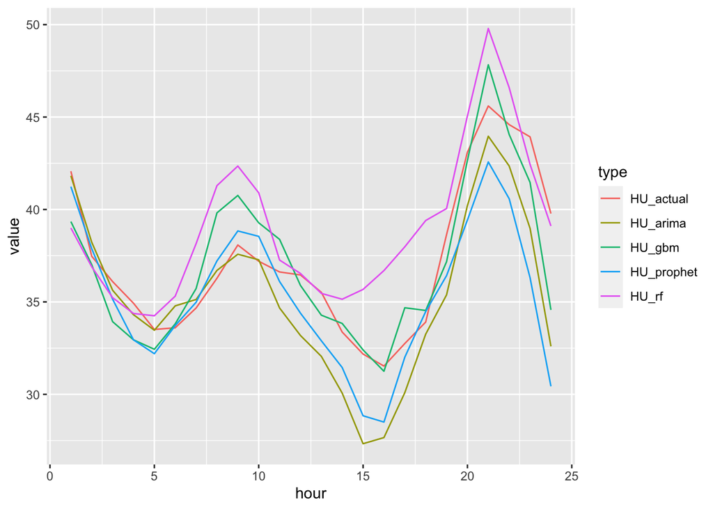

```r
data_HU=data.frame(hour=rep(1:24,5),
                type=c(rep("HU_actual",24),
                       rep("HU_arima",24),
                       rep("HU_prophet",24),
                       rep("HU_rf",24),
                       rep("HU_gbm",24)),
                value=c(subset(prices,datum==test_dates)$HU,
                        forecast_arima_HU,
                        forecast_prophet_HU$yhat,
                        forecast_rf_HU,
                        forecast_gbm_HU))
ggplot(data_HU,aes(x=hour,y=value,color=type))+
  geom_line()
```

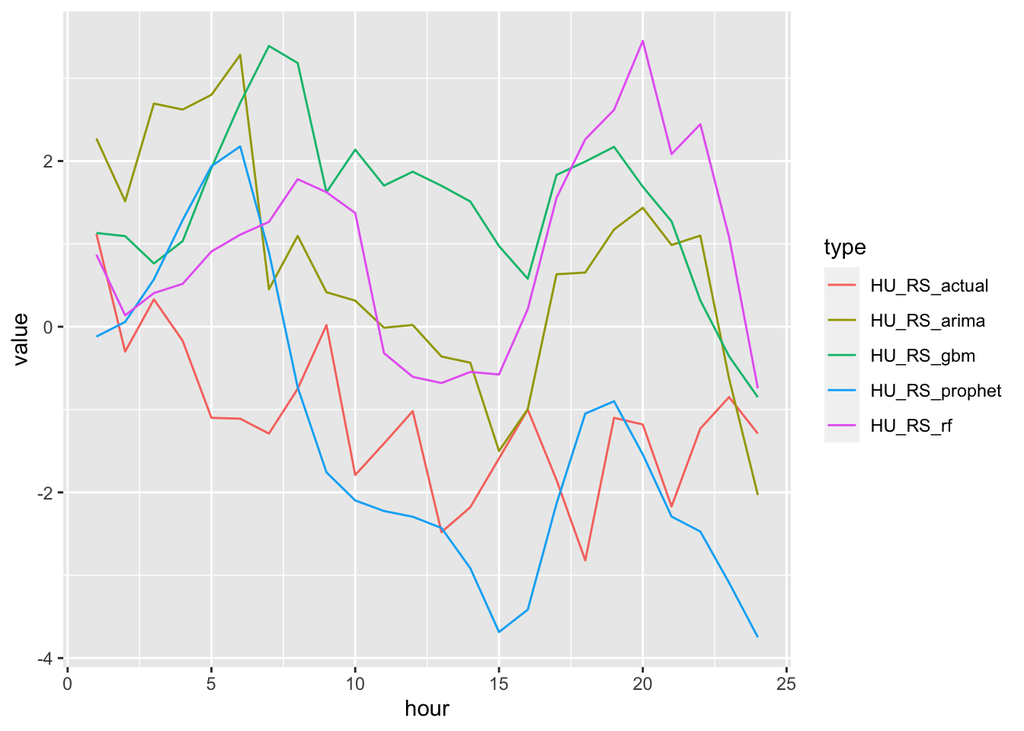

```r
data_HU_RS=data.frame(hour=rep(1:24,5),
                type=c(rep("HU_RS_actual",24),
                       rep("HU_RS_arima",24),
                       rep("HU_RS_prophet",24),
                       rep("HU_RS_rf",24),
                       rep("HU_RS_gbm",24)),
                value=c(subset(prices,datum==test_dates)$HU_RS,
                        forecast_arima_HU_RS,
                        forecast_prophet_HU_RS$yhat,
                        forecast_rf_HU_RS,
                        forecast_gbm_HU_RS))
ggplot(data_HU_RS,aes(x=hour,y=value,color=type))+
  geom_line()
```

## Decomposition based on prophet

The decomposition gives useful tips on which time of day, weekday, and month have higher values of the dependent variable based on the decomposition model (Prophet). For the HU model

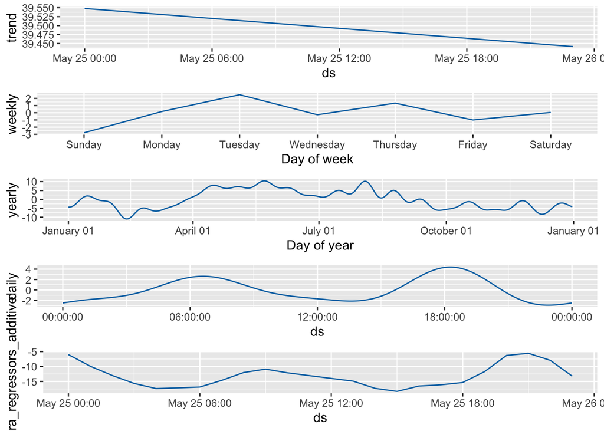

```r
prophet_plot_components(m_HU, forecast_prophet_HU)
```

For the HU-RS model

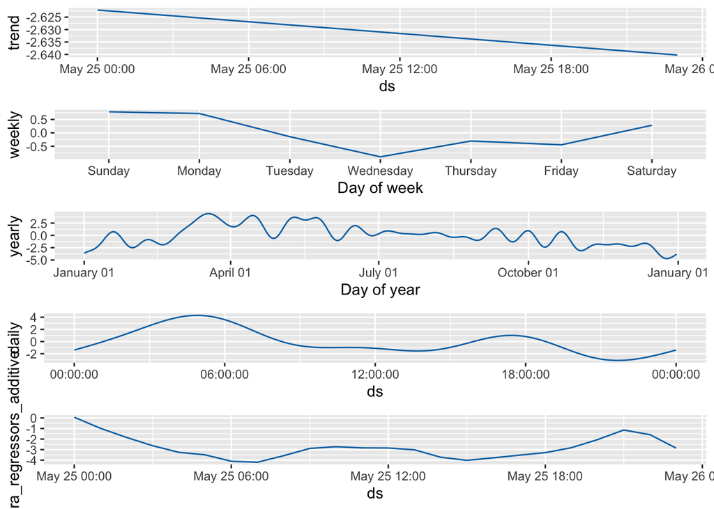

```r
prophet_plot_components(m_HU_RS, forecast_prophet_HU_RS)
```

## Variable importance (based on GBM algorithm which has a good built-in functionality for variable importance assessment)

*rel.inf* reflects % contribution of each variable to the model’s explanatory power. Some of the variables have 0% contribution, which is fine - the model captures a lot of interactions between features and some of them may already contain what a traditional model would regard as the effect of a particular hour of the day, etc.

For the HU model

```r
summary(gbm_HU,plotit = FALSE)
```

```
##                                 var      rel.inf
## HU_lag24                   HU_lag24 35.166084013
## RS_lag24                   RS_lag24 30.507003302
## FLoadHU                     FLoadHU 18.373348498
## FLoadHU_lag24         FLoadHU_lag24  2.994942245
## WGenRO                       WGenRO  1.871060973
## weekday_Monday       weekday_Monday  1.588676565
## weekday_Sunday       weekday_Sunday  1.034415928
## WGenRO_lag24           WGenRO_lag24  0.896564730
## GenHU                         GenHU  0.839117018
## GenHU_lag24             GenHU_lag24  0.744858176
## TempHU_lag2             TempHU_lag2  0.540249097
## FLoadHU_lag1           FLoadHU_lag1  0.495499538
## WGenRO_lag2             WGenRO_lag2  0.404781110
## WGenRO_lag1             WGenRO_lag1  0.404323559
## weekday_Saturday   weekday_Saturday  0.401863273
## FLoadHU_lag2           FLoadHU_lag2  0.374838201
## TempHU_lag1             TempHU_lag1  0.355462855
## TempHU                       TempHU  0.352132999
## TempHU_lag24           TempHU_lag24  0.307090801
## Holiday                     Holiday  0.295360071
## month_February       month_February  0.231809070
## month_March             month_March  0.209385831
## month_November       month_November  0.161441003
## month_August           month_August  0.154837963
## GenHU_lag2               GenHU_lag2  0.153207332
## month_October         month_October  0.132450572
## weekday_Tuesday     weekday_Tuesday  0.123246275
## DHour_H08                 DHour_H08  0.107835184
## DHour_H07                 DHour_H07  0.097295086
## DHour_H20                 DHour_H20  0.081931143
## GenHU_lag1               GenHU_lag1  0.077353501
## DHour_H19                 DHour_H19  0.062164121
## month_September     month_September  0.057139583
## DHour_H06                 DHour_H06  0.055040407
## DHour_H09                 DHour_H09  0.050868899
## DHour_H24                 DHour_H24  0.035002219
## month_July               month_July  0.029926626
## month_January         month_January  0.027202930
## DHour_H14                 DHour_H14  0.025053440
```

[output cut: 8 more lines]

```
## weekday_Wednesday weekday_Wednesday  0.012277663
## DHour_H16                 DHour_H16  0.008085901
## DHour_H10                 DHour_H10  0.005063234
## DHour_H13                 DHour_H13  0.005031410
## DHour_H23                 DHour_H23  0.004894838
## DHour_H03                 DHour_H03  0.004166054
## weekday_Thursday   weekday_Thursday  0.000000000
## month_June               month_June  0.000000000
## month_May                 month_May  0.000000000
## DHour_H04                 DHour_H04  0.000000000
## DHour_H05                 DHour_H05  0.000000000
## DHour_H11                 DHour_H11  0.000000000
## DHour_H12                 DHour_H12  0.000000000
## DHour_H17                 DHour_H17  0.000000000
## DHour_H22                 DHour_H22  0.000000000
```

For the HU-RS model

```r
summary(gbm_HU_RS,plotit = FALSE)
```

```
##                                 var     rel.inf
## RS_lag24                   RS_lag24 23.93413788
## FLoadHU                     FLoadHU 11.45393545
## GenHU                         GenHU  8.99351198
## HU_lag24                   HU_lag24  8.16564856
## GenHU_lag1               GenHU_lag1  6.12070068
## GenHU_lag2               GenHU_lag2  5.74812855
## FLoadHU_lag24         FLoadHU_lag24  5.10378507
## TempHU_lag24           TempHU_lag24  3.71537725
## TempHU                       TempHU  2.99746392
## GenHU_lag24             GenHU_lag24  2.49840801
## WGenRO                       WGenRO  2.31901039
## TempHU_lag1             TempHU_lag1  2.06130556
## TempHU_lag2             TempHU_lag2  1.91347952
## FLoadHU_lag1           FLoadHU_lag1  1.61450477
## WGenRO_lag24           WGenRO_lag24  1.59395557
## month_March             month_March  1.36518340
## FLoadHU_lag2           FLoadHU_lag2  1.28184187
## WGenRO_lag1             WGenRO_lag1  1.10279746
## DHour_H07                 DHour_H07  0.80483741
## DHour_H06                 DHour_H06  0.68493029
## WGenRO_lag2             WGenRO_lag2  0.63789889
## DHour_H08                 DHour_H08  0.59632972
## Holiday                     Holiday  0.56057115
## DHour_H24                 DHour_H24  0.52628414
## DHour_H23                 DHour_H23  0.45401431
## month_January         month_January  0.44206401
## DHour_H19                 DHour_H19  0.42239295
## DHour_H22                 DHour_H22  0.36910499
## DHour_H01                 DHour_H01  0.36296456
## month_December       month_December  0.33576002
## DHour_H05                 DHour_H05  0.25909718
## DHour_H20                 DHour_H20  0.25005008
## DHour_H18                 DHour_H18  0.18122546
## month_May                 month_May  0.17116215
## month_February       month_February  0.15612907
## DHour_H14                 DHour_H14  0.11798747
## DHour_H02                 DHour_H02  0.11642944
## weekday_Tuesday     weekday_Tuesday  0.11078671
## weekday_Sunday       weekday_Sunday  0.09058457
```

[output cut: 8 more lines]

```
## weekday_Saturday   weekday_Saturday  0.00000000
## weekday_Thursday   weekday_Thursday  0.00000000
## weekday_Wednesday weekday_Wednesday  0.00000000
## month_April             month_April  0.00000000
## month_August           month_August  0.00000000
## month_July               month_July  0.00000000
## month_June               month_June  0.00000000
## month_November       month_November  0.00000000
## month_October         month_October  0.00000000
## month_September     month_September  0.00000000
## DHour_H03                 DHour_H03  0.00000000
## DHour_H10                 DHour_H10  0.00000000
## DHour_H11                 DHour_H11  0.00000000
## DHour_H12                 DHour_H12  0.00000000
## DHour_H16                 DHour_H16  0.00000000
```